# clustering

## Algoritmos de Inteligência Artificial para clusterização

### 1. Infraestrutura

##### 1. Você está rodando em Python 3.9+:

- Sim, a versão que utilizei no projeto foi a 3.10.12.

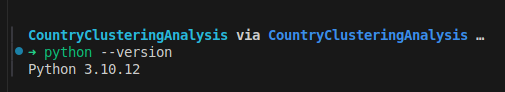

##### 2. Você está usando um ambiente virtual: Virtualenv ou Anaconda:

- Sim, a imagem abaixo informa o caminho que o ambiente virtual está sendo executado.

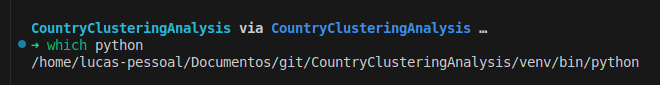

##### 3. Todas as bibliotecas usadas nesse exercícios estão instaladas em um ambiente virtual específico:

- Sim, todas as bibliotecas usadas foram instaladas no ambiente virtual.

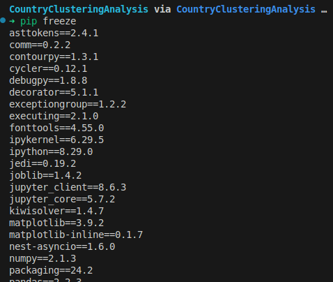

##### 4. Gere um arquivo de requerimentos (requirements.txt) com os pacotes necessários. É necessário se certificar que a versão do pacote está disponibilizada.

- Os pacotes foram salvos em um arquivo (requirements.txt) que está disponível no repositório.

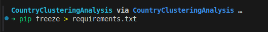

##### 5. Tire um printscreen do ambiente que será usado rodando em sua máquina.

- Abaixo imagem que mostra o ambiente em execução.

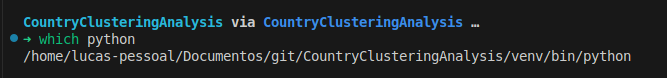

##### 6. Disponibilize os códigos gerados, assim como os artefatos acessórios (requirements.txt) e instruções em um repositório GIT público. (se isso não for feito, o diretório com esses arquivos deverá ser enviado compactado no moodle).

- Segue link para o repositório do github lá é possível encontrar toda a documentação para execução do projeto: https://github.com/lucasmaiamoreira/CountryClusteringAnalysis

### 2 - Escolha de base de dados

##### 1. Baixe os dados disponibilizados na plataforma Kaggle sobre dados sócio-econômicos e de saúde que determinam o índice de desenvolvimento de um país. Esses dados estão disponibilizados através do link: https://www.kaggle.com/datasets/rohan0301/unsupervised-learning-on-country-data.

- O Download foi realizado e está dentro da pasta "archive" com o nome Country-data.csv.

##### 2. Quantos países existem no dataset?

- O número de países no dataset é 167

##### 3. Mostre através de gráficos a faixa dinâmica das variáveis que serão usadas nas tarefas de clusterização. Analise os resultados mostrados. O que deve ser feito com os dados antes da etapa de clusterização?

- Antes da clusterização, deve-se:
- Normalizar os dados para que todas as variáveis tenham a mesma escala.
- Tratar valores ausentes.
- Verificar e remover possíveis outliers.

```python
# Importando as bibliotecas
import pandas as pd
import numpy as np
import matplotlib.pyplot as plt
import seaborn as sns
from sklearn.preprocessing import StandardScaler
from sklearn.cluster import KMeans
from scipy.cluster.hierarchy import linkage, dendrogram
from sklearn.cluster import AgglomerativeClustering
import scipy.cluster.hierarchy as sch
```

```python
# 1. Carregando os dados
dataset_path = "archive/Country-data.csv"
df = pd.read_csv(dataset_path)

# 2. Exibindo as primeiras linhas do dataset
print("Primeiras linhas do dataset:")
df.head()
```

```
Primeiras linhas do dataset:
```

|  | country | child_mort | exports | health | imports | income | inflation | life_expec | total_fer | gdpp |
| --- | --- | --- | --- | --- | --- | --- | --- | --- | --- | --- |
| 0 | Afghanistan | 90.2 | 10.0 | 7.58 | 44.9 | 1610 | 9.44 | 56.2 | 5.82 | 553 |
| 1 | Albania | 16.6 | 28.0 | 6.55 | 48.6 | 9930 | 4.49 | 76.3 | 1.65 | 4090 |
| 2 | Algeria | 27.3 | 38.4 | 4.17 | 31.4 | 12900 | 16.10 | 76.5 | 2.89 | 4460 |
| 3 | Angola | 119.0 | 62.3 | 2.85 | 42.9 | 5900 | 22.40 | 60.1 | 6.16 | 3530 |
| 4 | Antigua and Barbuda | 10.3 | 45.5 | 6.03 | 58.9 | 19100 | 1.44 | 76.8 | 2.13 | 12200 |

```python
# 3. Quantidade de países no dataset
num_paises = df.shape[0]
print(f"\nNúmero de países no dataset: {num_paises}")
```

```
Número de países no dataset: 167
```

```python
# 4. Informações gerais do dataset
print("\nInformações do dataset:")
display(df.info())
```

```
Informações do dataset:
<class 'pandas.core.frame.DataFrame'>
RangeIndex: 167 entries, 0 to 166
Data columns (total 10 columns):
 #   Column      Non-Null Count  Dtype
---  ------      --------------  -----
 0   country     167 non-null    object
 1   child_mort  167 non-null    float64
 2   exports     167 non-null    float64
 3   health      167 non-null    float64
 4   imports     167 non-null    float64
 5   income      167 non-null    int64
 6   inflation   167 non-null    float64
 7   life_expec  167 non-null    float64
 8   total_fer   167 non-null    float64
 9   gdpp        167 non-null    int64
dtypes: float64(7), int64(2), object(1)
memory usage: 13.2+ KB
```

```
None
```

```python
# 5. Estatísticas descritivas
print("\nEstatísticas descritivas:")
display(df.describe())
```

```
Estatísticas descritivas:
```

|  | child_mort | exports | health | imports | income | inflation | life_expec | total_fer | gdpp |
| --- | --- | --- | --- | --- | --- | --- | --- | --- | --- |
| count | 167.000000 | 167.000000 | 167.000000 | 167.000000 | 167.000000 | 167.000000 | 167.000000 | 167.000000 | 167.000000 |
| mean | 38.270060 | 41.108976 | 6.815689 | 46.890215 | 17144.688623 | 7.781832 | 70.555689 | 2.947964 | 12964.155689 |
| std | 40.328931 | 27.412010 | 2.746837 | 24.209589 | 19278.067698 | 10.570704 | 8.893172 | 1.513848 | 18328.704809 |
| min | 2.600000 | 0.109000 | 1.810000 | 0.065900 | 609.000000 | -4.210000 | 32.100000 | 1.150000 | 231.000000 |
| 25% | 8.250000 | 23.800000 | 4.920000 | 30.200000 | 3355.000000 | 1.810000 | 65.300000 | 1.795000 | 1330.000000 |
| 50% | 19.300000 | 35.000000 | 6.320000 | 43.300000 | 9960.000000 | 5.390000 | 73.100000 | 2.410000 | 4660.000000 |
| 75% | 62.100000 | 51.350000 | 8.600000 | 58.750000 | 22800.000000 | 10.750000 | 76.800000 | 3.880000 | 14050.000000 |
| max | 208.000000 | 200.000000 | 17.900000 | 174.000000 | 125000.000000 | 104.000000 | 82.800000 | 7.490000 | 105000.000000 |

```python
# 6. Visualizar a faixa dinâmica das variáveis
# Excluindo a coluna "country", que não será usada na clusterização
data_for_clustering = df.drop("country", axis=1)
```

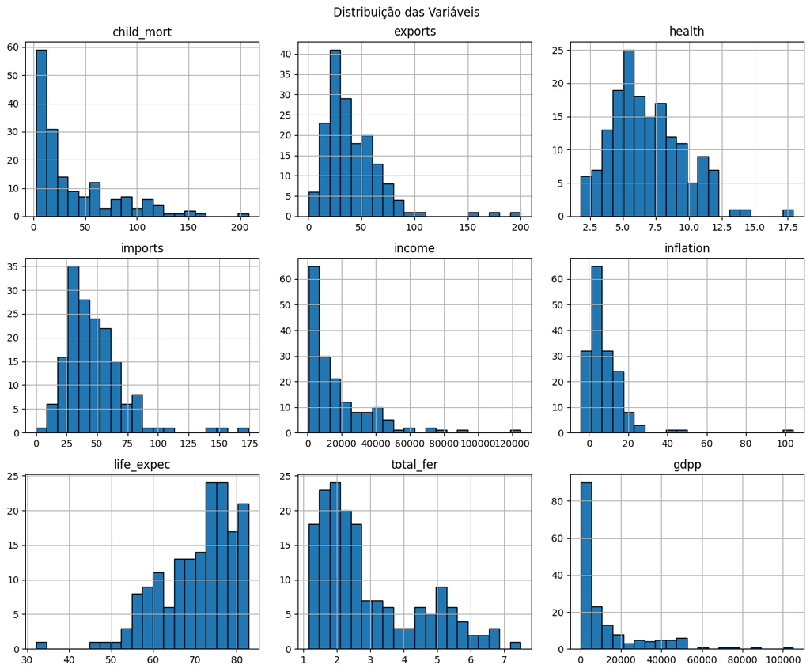

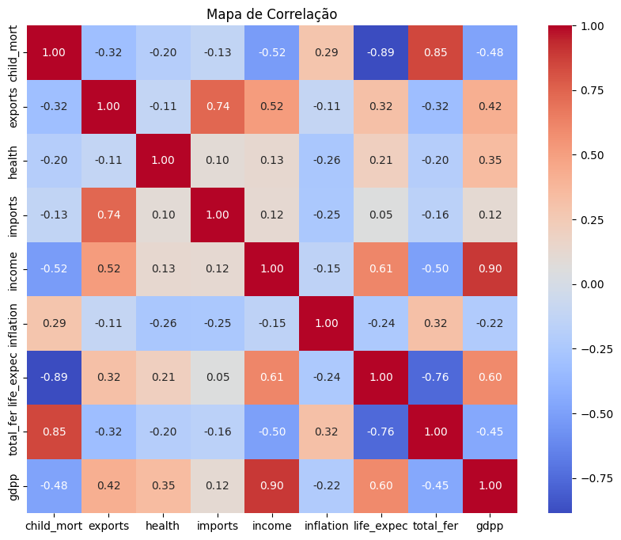

```
Antes da clusterização, deve-se:
- Normalizar os dados para que todas as variáveis tenham a mesma escala.
- Tratar valores ausentes.
- Verificar e remover possíveis outliers.
```

```python
# Plotar histogramas para cada variável
data_for_clustering.hist(figsize=(12, 10), bins=20, edgecolor="black")
plt.suptitle("Distribuição das Variáveis")
plt.tight_layout()
plt.show()

# Análise de correlação para identificar relações entre variáveis
plt.figure(figsize=(10, 8))
sns.heatmap(data_for_clustering.corr(), annot=True, cmap="coolwarm", fmt=".2f")
plt.title("Mapa de Correlação")
plt.show()

# 7. O que deve ser feito antes da clusterização
print("\nAntes da clusterização, deve-se:")
print("- Normalizar os dados para que todas as variáveis tenham a mesma escala.")
print("- Tratar valores ausentes.")
print("- Verificar e remover possíveis outliers.")
```

##### 4. Realize o pré-processamento adequado dos dados.

```
Dados após normalização (primeiras linhas):
```

|  | child_mort | exports | health | imports | income | inflation | life_expec | total_fer | gdpp |
| --- | --- | --- | --- | --- | --- | --- | --- | --- | --- |
| 0 | 1.291532 | -1.138280 | 0.279088 | -0.082455 | -0.808245 | 0.157336 | -1.619092 | 1.902882 | -0.679180 |
| 1 | -0.538949 | -0.479658 | -0.097016 | 0.070837 | -0.375369 | -0.312347 | 0.647866 | -0.859973 | -0.485623 |
| 2 | -0.272833 | -0.099122 | -0.966073 | -0.641762 | -0.220844 | 0.789274 | 0.670423 | -0.038404 | -0.465376 |
| 3 | 2.007808 | 0.775381 | -1.448071 | -0.165315 | -0.585043 | 1.387054 | -1.179234 | 2.128151 | -0.516268 |
| 4 | -0.695634 | 0.160668 | -0.286894 | 0.497568 | 0.101732 | -0.601749 | 0.704258 | -0.541946 | -0.041817 |

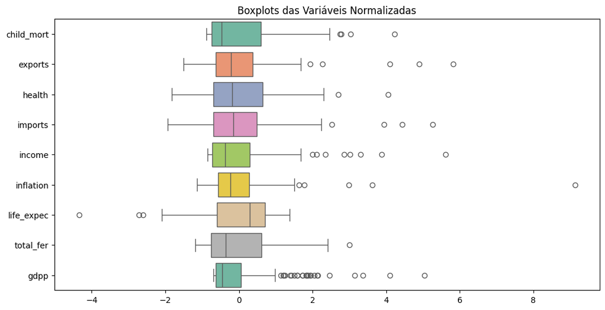

```
Os dados foram pré-processados e estão prontos para clusterização.
```

```python
# 8. Pré-processamento dos dados

# Normalização dos dados
scaler = StandardScaler()
normalized_data = scaler.fit_transform(data_for_clustering)

# Converter de volta para um DataFrame para facilitar a visualização
normalized_df = pd.DataFrame(normalized_data, columns=data_for_clustering.columns)

# Verificar os dados normalizados
print("\nDados após normalização (primeiras linhas):")
display(normalized_df.head())

# 9. Visualização dos dados normalizados
# Boxplots das variáveis normalizadas
plt.figure(figsize=(12, 6))
sns.boxplot(data=normalized_df, orient="h", palette="Set2")
plt.title("Boxplots das Variáveis Normalizadas")
plt.show()

# Dados prontos para a etapa de clusterização!
print("\nOs dados foram pré-processados e estão prontos para clusterização.")
```

### 3 - Clusterização

##### 1. Realizar o agrupamento dos países em 3 grupos distintos. Para tal, use:

- K-Médias

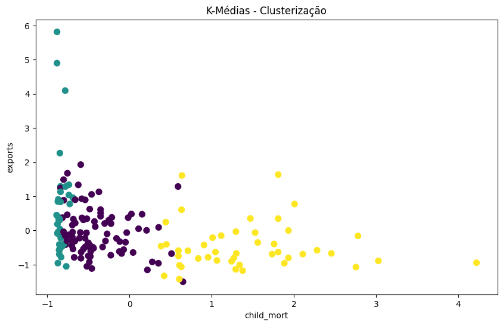

```
Clusters formados pelo K-Médias:
```

| Cluster_KMeans | child_mort | exports | health | imports | income | inflation | life_expec | total_fer | gdpp |
| --- | --- | --- | --- | --- | --- | --- | --- | --- | --- |
| 0 | -0.393282 | -0.030584 | -0.206179 | 0.019562 | -0.250930 | -0.005783 | 0.226762 | -0.402579 | -0.355832 |
| 1 | -0.827449 | 0.645080 | 0.727411 | 0.190639 | 1.484243 | -0.484921 | 1.079579 | -0.791877 | 1.615995 |
| 2 | 1.413564 | -0.457615 | -0.187898 | -0.189897 | -0.707839 | 0.398989 | -1.297031 | 1.402874 | -0.612761 |

```python
# Normalização dos dados
scaler = StandardScaler()
normalized_data = scaler.fit_transform(data_for_clustering)

# Converter de volta para um DataFrame para facilitar a visualização
normalized_df = pd.DataFrame(normalized_data, columns=data_for_clustering.columns)

# Definir o número de clusters
n_clusters = 3

# Aplicar K-Médias
kmeans = KMeans(n_clusters=n_clusters, random_state=42)
clusters_kmeans = kmeans.fit_predict(normalized_df)

# Adicionar o cluster resultante ao DataFrame
normalized_df['Cluster_KMeans'] = clusters_kmeans

# Visualizar os clusters
plt.figure(figsize=(10, 6))
plt.scatter(normalized_df.iloc[:, 0], normalized_df.iloc[:, 1], c=clusters_kmeans, cmap='viridis', s=50)
plt.title("K-Médias - Clusterização")
plt.xlabel(normalized_df.columns[0])
plt.ylabel(normalized_df.columns[1])
plt.show()

# Verificar como os dados estão agrupados
print("\nClusters formados pelo K-Médias:")
display(normalized_df.groupby('Cluster_KMeans').mean())
```

- Clusterização Hierárquica

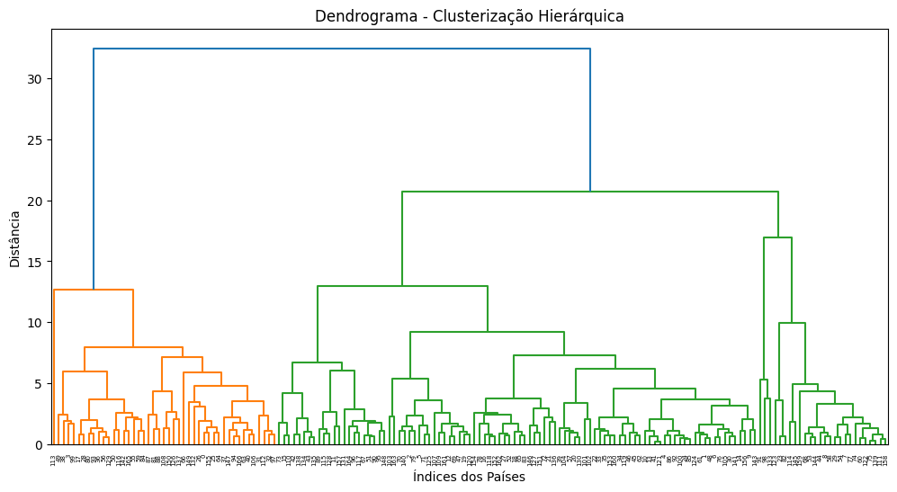

```
Clusters formados pela Clusterização Hierárquica:
```

| Cluster_Hierarchical | child_mort | exports | health | imports | income | inflation | life_expec | total_fer | gdpp | Cluster_KMeans |
| --- | --- | --- | --- | --- | --- | --- | --- | --- | --- | --- |
| 0 | -0.829075 | 0.479846 | 0.849284 | -0.019194 | 1.642774 | -0.470226 | 1.145417 | -0.775624 | 1.854135 | 1.000000 |
| 1 | 1.413564 | -0.457615 | -0.187898 | -0.189897 | -0.707839 | 0.398989 | -1.297031 | 1.402874 | -0.612761 | 2.000000 |
| 2 | -0.438067 | 0.084549 | -0.141937 | 0.094213 | -0.113119 | -0.059673 | 0.297766 | -0.447532 | -0.214930 | 0.104167 |

```python
# Realizar o linkage
Z = linkage(normalized_df, method='ward')

# Visualizar o dendrograma
plt.figure(figsize=(12, 6))
dendrogram(Z)
plt.title("Dendrograma - Clusterização Hierárquica")
plt.xlabel("Índices dos Países")
plt.ylabel("Distância")
plt.show()

# Aplicar a clusterização hierárquica com 3 clusters
hierarchical = AgglomerativeClustering(n_clusters=3, linkage='ward')
clusters_hierarchical = hierarchical.fit_predict(normalized_df)

# Adicionar o cluster resultante ao DataFrame
normalized_df['Cluster_Hierarchical'] = clusters_hierarchical

# Verificar como os dados estão agrupados
print("\nClusters formados pela Clusterização Hierárquica:")
display(normalized_df.groupby('Cluster_Hierarchical').mean())
```

##### 2. Para os resultados, do K-Médias:

- Interprete cada um dos clusters obtidos citando:
  - Qual a distribuição das dimensões em cada grupo;
  - O país, de acordo com o algoritmo, melhor representa o seu agrupamento. Justifique;
- Cluster 0: Países de Desenvolvimento Intermediário Características principais: Esse cluster parece representar países que estão em um estágio intermediário de desenvolvimento. Eles possuem níveis médios de expectativa de vida e mortalidade infantil. O nível de renda é baixo a médio, e os índices de saúde e educação são razoáveis, mas não se destacam entre os países mais desenvolvidos. Esses países podem estar em transição econômica, com alguns avanços, mas ainda enfrentando desafios em termos de infraestrutura, acesso à saúde e desigualdade social. Sua economia é razoavelmente diversificada, mas ainda depende de importações e exportações limitadas.
  - País típico: Um exemplo de país que poderia representar este cluster seria um país como Brasil ou África do Sul. Esses países têm um desenvolvimento econômico moderado, com bons índices de expectativa de vida e saúde em algumas áreas, mas ainda enfrentam desafios econômicos e sociais.
- Cluster 1: Países Altamente Desenvolvidos Características principais: O Cluster 1 engloba países altamente desenvolvidos, com expectativa de vida alta, baixa mortalidade infantil e alta renda per capita. Estes países possuem sistemas de saúde avançados, boa infraestrutura, e estão entre as maiores economias globais. Sua produção e exportação são significativas, e os níveis de educação são de alta qualidade. Além disso, têm uma boa estabilidade econômica e políticas públicas eficazes, refletindo seu status de desenvolvimento elevado.
  - País típico: Países como EUA, Alemanha, ou Japão podem ser exemplos claros desse cluster. Eles apresentam uma alta qualidade de vida, sistemas de saúde muito desenvolvidos e são grandes potências econômicas com alto poder de exportação.
- Cluster 2: Países em Desenvolvimento ou Subdesenvolvidos Características principais: O Cluster 2 representa países com baixo nível de desenvolvimento econômico. Eles enfrentam grandes desafios em termos de saúde pública, com alta mortalidade infantil e expectativa de vida baixa. A renda média também é muito baixa, e as importações e exportações são limitadas. Estes países ainda lidam com questões como desnutrição, acesso limitado a cuidados médicos de qualidade, e taxas de fertilidade mais altas. A infraestrutura e os serviços públicos muitas vezes são subdesenvolvidos.
  - País típico: Países como Índia, Nigéria ou Afeganistão podem se encaixar nesse cluster. Esses países têm altas taxas de pobreza, desigualdade social e baixos índices de expectativa de vida, com grandes desafios econômicos e sociais.

Resumo Qualitativo:

- Cluster 0: Países de desenvolvimento intermediário, com boas melhorias em expectativa de vida, mas ainda com desafios econômicos e sociais.
- Cluster 1: Países desenvolvidos, com alta qualidade de vida, saúde avançada, alta renda e grande poder econômico.
- Cluster 2: Países em desenvolvimento ou subdesenvolvidos, com baixos índices de saúde, alta mortalidade infantil e baixa renda.

##### 3. Para os resultados da Clusterização Hierárquica, apresente o dendograma e interprete os resultados.

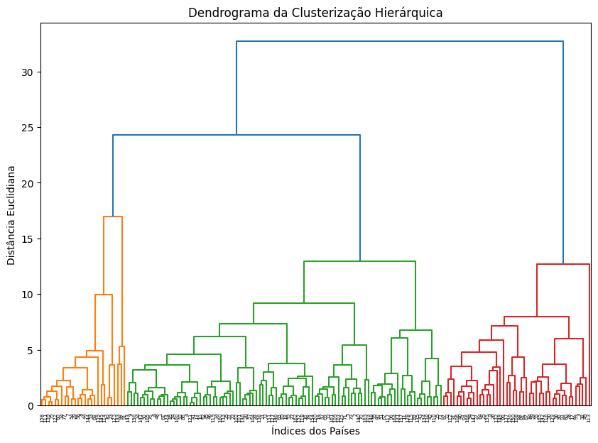

```python
# Realizar a clusterização hierárquica
linked = sch.linkage(normalized_df, method='ward')

# Gerar o dendrograma
plt.figure(figsize=(10, 7))
sch.dendrogram(linked, labels=normalized_df.index, orientation='top', distance_sort='descending', show_leaf_counts=True)
plt.title('Dendrograma da Clusterização Hierárquica')
plt.xlabel('Índices dos Países')
plt.ylabel('Distância Euclidiana')
plt.show()
```

#### 4. Compare os dois resultados, aponte as semelhanças e diferenças e interprete.

- Semelhanças:
  1. Três grupos: Tanto o K-Médias quanto a Clusterização Hierárquica formaram três grupos de países com características parecidas.
  2. Padrões semelhantes: Ambos os métodos separaram os países de acordo com o nível de desenvolvimento, com um grupo de países mais desenvolvidos, um de países intermediários e outro de países menos desenvolvidos.
- Diferenças:
  1. Definição dos grupos:
     - O K-Médias cria grupos mais bem definidos e com características bem separadas.
     - A Clusterização Hierárquica oferece uma visão mais detalhada das distâncias entre os países, criando grupos mais flexíveis.
  2. Características dos clusters:
     - No K-Médias, os grupos de países desenvolvidos têm renda mais baixa que no grupo da Clusterização Hierárquica, onde esses países têm renda mais alta.
     - A expectativa de vida e mortalidade infantil também variam de um método para o outro, com o K-Médias tendo algumas diferenças nas médias.
  3. Flexibilidade:
     - O K-Médias é mais rígido, porque ele define exatamente o número de grupos.
     - A Clusterização Hierárquica é mais flexível e mostra a distância entre os grupos.
- Conclusão:
  - Ambos os métodos mostram que os países podem ser agrupados em três tipos principais: mais desenvolvidos, intermediários e menos desenvolvidos.
  - As diferenças surgem porque o K-Médias é mais simples e cria grupos bem definidos, enquanto a Clusterização Hierárquica permite ver mais detalhes sobre as distâncias entre os grupos e é um pouco mais flexível na formação dos clusters.

### 4 - Escolha de algoritmos.

1. Escreva em tópicos as etapas do algoritmo de K-médias até sua convergência.
- Inicialização: Escolher um número de clusters (k) e selecionar aleatoriamente k pontos como centróides iniciais.
- Atribuição de Pontos: Atribuir cada ponto de dados ao cluster cujo centróide é o mais próximo, com base na distância Euclidiana.
- Recalcular os Centróides: Calcular o novo centróide de cada cluster como a média das posições de todos os pontos que pertencem a esse cluster.
- Repetir: Repetir os passos de atribuição de pontos e recalculo dos centróides até que os centróides não mudem mais ou o movimento entre os centróides seja mínimo (isto é, o algoritmo tenha convergido).
2. O algoritmo de K-médias converge até encontrar os centróides que melhor descrevem os clusters encontrados (até o deslocamento entre as interações dos centróides ser mínimo). Lembrando que o centróide é o baricentro do cluster em questão e não representa, em via de regra, um dado existente na base. Refaça o algoritmo apresentado na questão 1 a fim de garantir que o cluster seja representado pelo dado mais próximo ao seu baricentro em todas as iterações do algoritmo. Obs: nesse novo algoritmo, o dado escolhido será chamado medóide.

```
Clusters formados pelo K-Medoides:
```

| Cluster_KMedoids | child_mort | exports | health | imports | income | inflation | life_expec | total_fer | gdpp | Cluster_KMeans | Cluster_Hierarchical |
| --- | --- | --- | --- | --- | --- | --- | --- | --- | --- | --- | --- |
| 0.0 | 1.576923 | 0.479916 | -0.793083 | 0.050639 | -0.478977 | 2.313256 | -1.045303 | 1.600591 | -0.498887 | 1.750000 | 1.125000 |
| 1.0 | 1.065057 | -0.617283 | -0.175710 | -0.261902 | -0.714494 | 0.098982 | -1.135041 | 1.048321 | -0.623876 | 1.551020 | 1.224490 |
| 2.0 | -0.589120 | 0.240068 | 0.135949 | 0.112982 | 0.353109 | -0.212329 | 0.581631 | -0.583386 | 0.314191 | 0.327273 | 1.527273 |

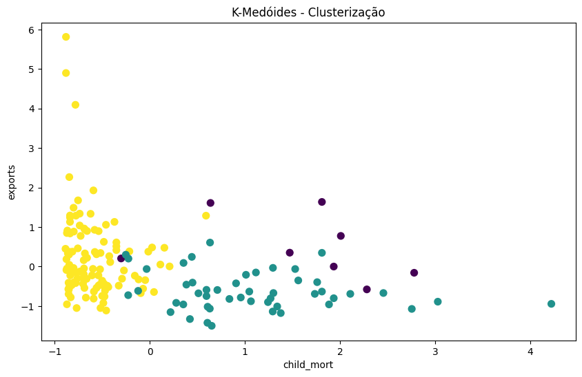

```python
# Função para calcular a distância Euclidiana
def euclidean_distance(a, b):
    return np.linalg.norm(a - b)

# Função para encontrar o medóide de um cluster
def calculate_medoid(cluster_points):
    distances = np.zeros(len(cluster_points))
    for i in range(len(cluster_points)):
        distances[i] = np.sum([euclidean_distance(cluster_points[i], other) for other in cluster_points])
    medoid_idx = np.argmin(distances)  # Escolhe o índice do ponto mais próximo
    return cluster_points[medoid_idx]

# Aplicando a modificação para usar Medóides
def k_medoids_algorithm(data, k, max_iters=100):
    # Inicialização: Escolher k pontos aleatórios como medóides
    medoids = data[np.random.choice(data.shape[0], k, replace=False)]
    labels = np.zeros(data.shape[0])

    for _ in range(max_iters):
        # Atribuir pontos ao cluster mais próximo do medóide
        for i in range(data.shape[0]):
            distances = [euclidean_distance(data[i], medoid) for medoid in medoids]
            labels[i] = np.argmin(distances)

        # Recalcular os medóides
        new_medoids = np.copy(medoids)
        for i in range(k):
            cluster_points = data[labels == i]
            new_medoids[i] = calculate_medoid(cluster_points)

        # Se os medóides não mudaram, o algoritmo convergiu
        if np.array_equal(medoids, new_medoids):
            break
        medoids = np.copy(new_medoids)

    return labels, medoids

# Normalização dos dados
scaler = StandardScaler()
normalized_data = scaler.fit_transform(data_for_clustering)

# Definir o número de clusters
n_clusters = 3

# Rodar o algoritmo de K-Medóides
labels_kmedoids, medoids_kmedoids = k_medoids_algorithm(normalized_data, n_clusters)

# Adicionar os resultados ao DataFrame
normalized_df['Cluster_KMedoids'] = labels_kmedoids

# Verificar como os dados estão agrupados
print("\nClusters formados pelo K-Medoides:")
display(normalized_df.groupby('Cluster_KMedoids').mean())

# Visualizar os clusters
plt.figure(figsize=(10, 6))
plt.scatter(normalized_df.iloc[:, 0], normalized_df.iloc[:, 1], c=labels_kmedoids, cmap='viridis', s=50)
plt.title("K-Medóides - Clusterização")
plt.xlabel(normalized_df.columns[0])
plt.ylabel(normalized_df.columns[1])
plt.show()
```

3. O Algoritmo de K-Médias é Sensível a Outliers nos Dados. Explique:
- O algoritmo de K-médias é sensível a outliers porque o centróide de cada cluster é calculado como a média dos pontos. Se houver outliers (pontos distantes), eles podem distorcer essa média e fazer o centróide se mover para uma posição que não represente bem o restante dos dados.
- Isso pode levar a uma atribuição incorreta de pontos aos clusters, já que o centróide pode ser influenciado por outliers e não representar corretamente o grupo de dados.
4. Por Que o Algoritmo de DBScan é Mais Robusto à Presença de Outliers?:
- O DBScan é mais robusto a outliers porque ele não usa médias para formar os clusters. Em vez disso, ele se baseia na densidade dos pontos.
- DBScan identifica clusters como regiões de alta densidade de pontos próximos uns aos outros.
- Outliers, que são pontos isolados ou em regiões de baixa densidade, são identificados como ruído e não são incluídos em nenhum cluster.
- Dessa forma, os outliers não afetam a formação dos clusters, o que torna o DBScan mais adequado para conjuntos de dados com outliers.